# DR. CARLOS MAURICIO PEREDO

## GEOSPATIAL VISUALIZATION ANALYSES

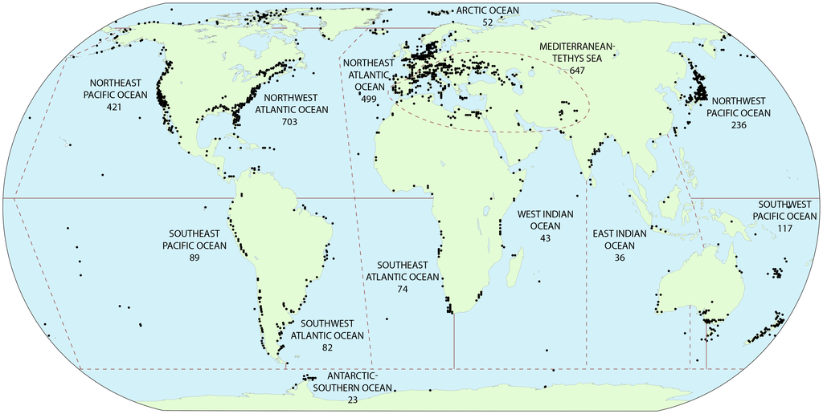

### PROJECT OVERVIEW

CLIENT  
Paleobiology Database

GOAL  
Develop a predictive model that forecasts the prevalence of marine mammal fossils across the globe.

PRIMARY TOOLS  
R & RStudio, GIS, Adobe Creative Suite

BACKGROUND  
The client is a non-governmental non-profit public resource for paleontological data. Their mission is to encourage and enable data-driven collaborative efforts that address large-scale paleobiological questions. The client requests a way to predict potential fossil localities to discover new fossils.

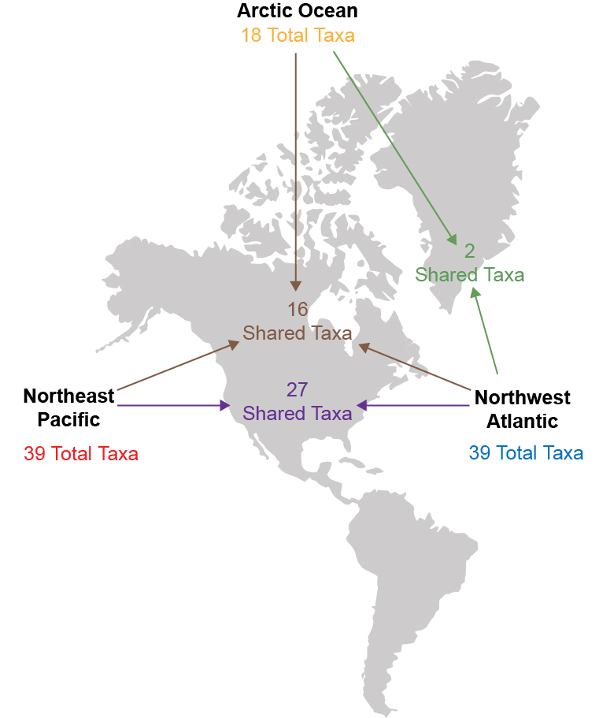

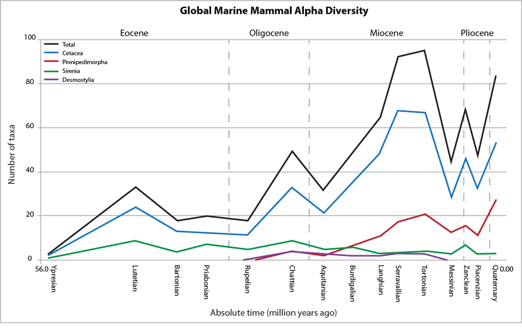

### CHALLENGES AND SOLUTIONS

**DIFFERENT ORGANISMS**

**The Challenge**: different groups of organisms have their distributions influenced by completely different factors.  
**The Solution**: develop independent models based on organisms with similar ecologies and geographic distributions to avoid homogeneity of the model.

**INHERENT BIAS**

**The Challenge**: fossil distribution is heavily biased by socioeconomic factors, such as GDP, which do not reflect a true biological or geologic signal.  
**The Solution**: standardize the dataset for GDP and other socioeconomic factors to avoid implicit Northern Hemisphere bias.

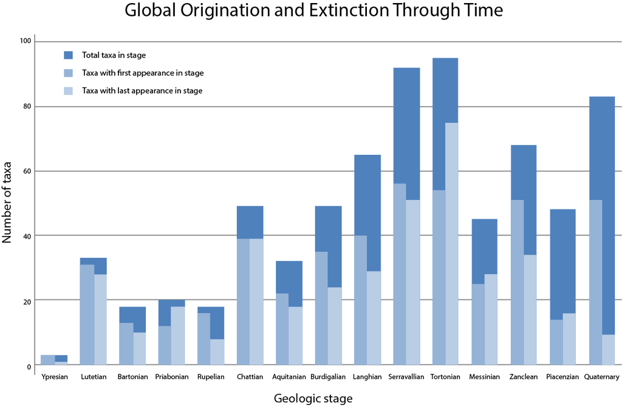

### NEXT STEPS

Now that we’ve delivered the model to the client, what’s next?

**EXPAND THE SCOPE**

Marine mammals were an ideal starting point because their distribution is easily modeled to modern coastlines. Now, we can expand to other fossil groups, including terrestrial organisms.

**UNITE DATASETS**

The dstribution of fossils is just the first step. A major factor is being able to excavate fossils is the surface exposure of the bedrock. By combinind our model with geologic maps from the USGS, we’ll be able to forecast high value localities for paleontologists to prospect.